## David’s Portfolio of Urban/Spatial Informatics Works + Real Estate Financial Models

Navigation:

- Real Estate Financial Modeling
- Urban/Spatial Informatics Modeling - Part I
- Urban/Spatial Informatics Modeling - Part II
- Urban/Spatial Informatics Modeling - Part III

*Last Updated on May 13, 2021*  
*Not to be confused with David’s Portfolio of Conceptual Art & Design*

### Selected Real Estate Finance & Investment coursework

### at the Wharton School (2020-2021)

- [Models for Case 2: Real Estate Private Equity Fund: Waterfall Structure (2021), David Pan & Theodore Lewis - REAL 840: Advanced Real Estate Investments and Analysis†](https://www.wharton.upenn.edu/)
- [Models for Case 1: Advanced Real Estate Proforma Analysis/ Land Purchase Price Estimation, Washington DC (2021), David Pan & Theodore Lewis - REAL 840†](https://www.wharton.upenn.edu/)

†Sharing of models is currently prohibited, please contact Wharton Real Estate Department for permission to view/evaluate

### Selected Urban/Spatial Informatics coursework

### at the MUSA program of the Weitzman School (2020-2021)

*Python, JS, R and SQL are the primary languages used*

- [Supervised Ensemble Machine Learning: Urban Real Estate Valuation Tool (Standalone & Portable) (Programmed in Python) - Independent Study Capstone Project Course under Professor Charles Dana Tomlin](https://youtu.be/G51Yo04meWQ)

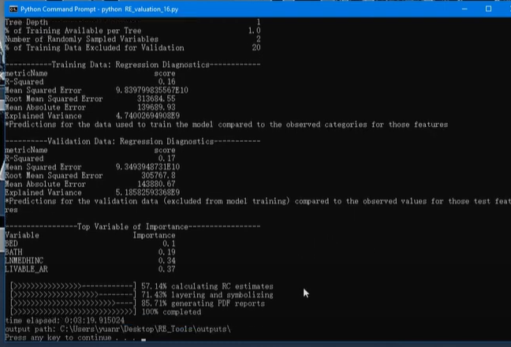

- [Heuristic/Unsupervised Machine Learning: Clustering Analysis of Chicago, IL, Population Characteristics (programmed in Python), Dec 2020 - MUSA 550 - Geospatial Data Science](https://yrpan.github.io/MUSA550_finalproject/clustering-analysis/)

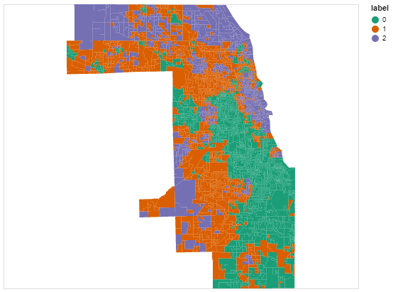

- Deep Learning: Multi-Class Land Cover Classification (CNN, Transfer Learning, & Comparatives) (Programmed in Python) - MUSA 650 - Geospatial Machine Learning in Remote Sensing

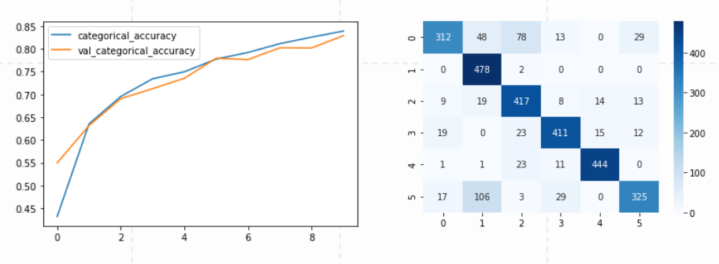

### Selected Urban/Spatial Informatics coursework

### at my undergraduate school UWaterloo (2014-2019)

- ADF Fusion Web App (programmed in SQL + JS Developer), 2016 - PLAN 387: Spatial Databases

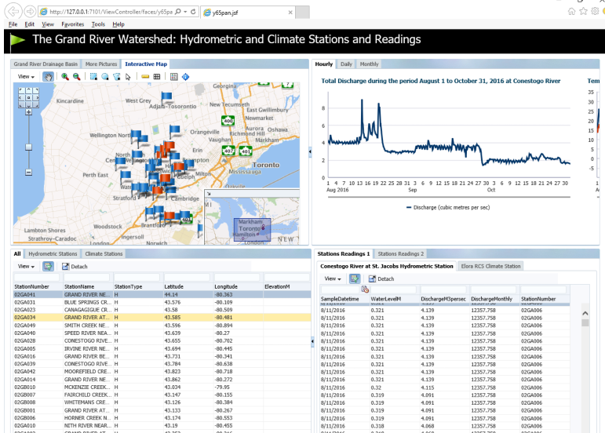

- SLUCE2 LMM ABM Lab Report/ Von Thunen Land Rent Model (software-based) - PLAN 416: Modeling the City

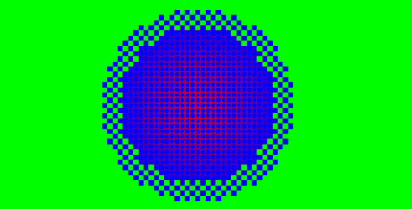

- IDRISI Markov Cellular Automata Lab/ Land Cover Projection (software-based) - PLAN 416: Modeling the City

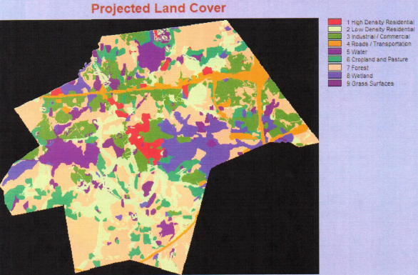

- SLUCE2 Hedonic Regression Lab Report (software-based) - PLAN 416: Modeling the City

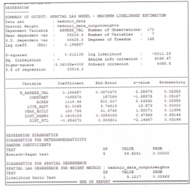

### Other relevant Urban/Spatial Informatics coursework at Penn:

- Supervised Machine Learning: Surface Object Detection: Segmentation & Classification (SVM) (programmed in Python) Mar 2021
- Supervised Machine Learning: Everyday Object Classification (K-NN & SVM) (programmed in Python) Feb 2021
- Detecting NDVI and urban structures on Woody Island using satellite bands (programmed in JS) Feb 2021
- Global Real Estate Development Suitability Model (programmed in JavaScript) Dec 2020
- Heuristic/Unsupervised Machine Learning: Clustering Analysis of Chicago, IL, Population Characteristics (programmed in Python) Dec 2020
- Heuristic/Unsupervised Machine Learning: K-Means Clustering, Philadelphia, PA (programmed in R) Dec 2020
- Point Pattern Analyses (NN, K-Functions), Philadelphia, PA (programmed in R) Dec 2020
- SLR Real Estate Damage Prediction Model for New York City, NY (programmed in Python) Dec 2020
- Supervised Machine Learning (Random Forest): Single-Family Home Price Prediction for Philadelphia, PA (programmed in Python) Dec 2020
- Supervised Machine Learning: Single-Family Home Price Prediction for Miami, FL (programmed in R) Dec 2020
- NDVI and Urban Network Analysis, Philadelphia, PA (programmed in Python) Oct 2020 – Nov 2020
- Spatial Lag, Spatial Error, GWR Median House Price Prediction for Philadelphia, PA (ArcGIS + R) Nov 2020
- Global Cumulative Travel Cost Estimation (programmed in JavaScript) Oct 2020
- Supervised Machine Learning: Home Repair Tax Credits Benefit/Cost Prediction (programmed in R) Oct 2020
- Supervised Machine Learning: Narcotics-related Crime Prediction, Chicago, IL (programmed in R) Oct 2020

### Professional works at Environment Canada, Water Science & Technology (2018-2020)

From 2018 to mid 2020, David produced a series of spatial informatics models and tools to support different scientific research initiatives on inland waters, alongside senior Physical Scientists:

- **Potential role of sediment resuspension on nutrient dynamics in Lake of the Woods.** Reza Valipour, Ian Droppo, Johann Biberhofer, Jun Zhao, and Yuanrong Pan (2020). Environment Canada, Water Science and Technology. 2020 International Lake of the Woods Watershed Forum *[Physical Science Publication]*.

[figure not shown]

- [Water Chemical Concentration – Averaging & Hotspot Toolset (programmed in Python), 2019 – 2020†](https://www.canada.ca/en/environment-climate-change.html)
- [Water Sediment Fractions Prediction and Interpolation Toolset (programmed in Python), 2019 – 2020†](https://www.canada.ca/en/environment-climate-change.html)
- [Water Sediment Thickness Prediction and Interpolation Toolset (programmed in Python), 2019 – 2020†](https://www.canada.ca/en/environment-climate-change.html)
- [Water Sediment Data Plotting Toolset- Tracers, Heavy Metals, Soil Particles, Differences (programmed in Python), 2018 – 2019†](https://www.canada.ca/en/environment-climate-change.html)
- [IDW & Kernel Water Quality Parameters Interpolation Toolset (programmed in Python), 2018†](https://www.canada.ca/en/environment-climate-change.html)

†Sharing of models and tools is currently prohibited, please contact Environment Canada, Science & Technology Branch, for permission to view/evaluate

*DAVID’S PORTFOLIO OF URBAN/SPATIAL INFORMATICS & REAL ESTATE FINANCIAL MODELING (2014-2021)*